# **Project - Mushroom Classification**

- Student name: **DIVYA RAY**

# **Project Outline**

The Module began by introducing time series visualizations and trend identification. Then a deeper understanding of K-Nearest-Neighbors was provided along with model evaluation metrics. Following up, Module 3 initiated the disciplines of graph theory, clustering networks, and recommendation systems. Around the midpoint of the module, the curriculum dives into logistic regression, ROC curves, and class imbalance problems. Decision trees, random forests, and ensemble methods then gave a wholesome look into the powers of machine learning. Finally the lessons of SVM, clustering, and dimensionality reduction allowed for a satisfying conclusion to the module.

In this project, I will be working with Mushroom Classification.

## Data Information

The data set contains 8124 rows and the following 23 features:

`class`: edible(e) or poisonous(p)

`cap-shape`: bell(b), conical(c), convex(x), flat(f), knobbed(k), sunken(s)

`cap-surface`: fibrous(f), grooves(g), scaly(y), smooth(s)

`cap-color`: brown(n), buff(b), cinnamon(c), gray(g), green(r), pink(p), purple(u), red(e), white(w), yellow(y)

`bruises`: bruises(t), no bruises(f)

`odor`: almond(a), anise(l), creosote(c), fishy(y), foul(f), musty(m), none(n), pungent(p), spicy(s)

`gill-attachment`: attached(a), descending(d), free(f), notched(n)

`gill-spacing`: close(c), crowded(w), distant(d)

`gill-size`: broad(b), narrow(n)

`gill-color`: black(k), brown(n), buff(b), chocolate(h), gray(g), green(r), orange(o), pink(p), purple(u), red(e), white(w), yellow(y)

`stalk-shape`: enlarging(e), tapering(t)

`stalk-root`: bulbous(b), club(c), cup(u), equal(e), rhizomorphs(z), rooted(r), missing(?)

`stalk-surface-above-ring`: fibrous(f), scaly(y), silky(k), smooth(s)

`stalk-surface-below-ring`: fibrous(f), scaly(y), silky(k), smooth(s)

`stalk-color-above-ring`: brown(n), buff(b), cinnamon(c), gray(g), orange(o), pink(p), red(e), white(w), yellow(y)

`stalk-color-below-ring`: brown(n), buff(b), cinnamon(c), gray(g), orange(o), pink(p), red(e), white(w), yellow(y)

`veil-type`: partial(p), universal(u)

`veil-color`: brown(n), orange(o), white(w), yellow(y)

`ring-number`: none(n), one(o), two(t)

`ring-type`: cobwebby(c), evanescent(e), flaring(f), large(l), none(n), pendant(p), sheathing(s), zone(z)

`spore-print-color`: black(k), brown(n), buff(b), tan(h), green(r), orange(o), purple(u), white(w), yellow(y)

`population`: abundant(a), clustered(c), numerous(n), scattered(s), several(v), solitary(y)

`habitat`: grasses(g), leaves(l), meadows(m), paths(p), urban(u), waste(w), woods(d)

# **Project PreWork**

Before moving forward with classification, there are necessary steps to become familiar with the Mushroom Dataset. First, importing libraries needed to complete an exploratory analysis of the data would be helpful. Then it's important to examine the features within the dataset. What are the qualities of each species? What characteristics make them similar or different? What characteristics are most important for classification? Questions like these will help develop a better understanding of the dataset and will eventually guide effective classification.

## Import Libraries

```python
# Import Pandas
import pandas as pd

# Import Numpy
import numpy as np

# Import SciPy
from scipy import stats
from scipy.special import comb
import math

# Import StatsModels
import statsmodels.api as sm
from statsmodels.formula.api import ols

# Import SkLearn
from sklearn.utils import resample
from sklearn.ensemble import RandomForestClassifier as RFC
from sklearn.tree import DecisionTreeClassifier as DTC
from sklearn import preprocessing as pp
from sklearn.linear_model import LogisticRegression as LR
from sklearn.neighbors import KNeighborsClassifier as KNN
from sklearn.preprocessing import LabelEncoder
from sklearn.preprocessing import StandardScaler
from sklearn.model_selection import train_test_split
from sklearn.model_selection import cross_val_score
from sklearn.model_selection import StratifiedShuffleSplit
from sklearn.decomposition import PCA
from sklearn.linear_model import LogisticRegression
from sklearn.metrics import accuracy_score
from sklearn import metrics
from sklearn.metrics import roc_curve, auc
from sklearn.model_selection import GridSearchCV
from sklearn.model_selection import RandomizedSearchCV
from sklearn.svm import SVC
from sklearn.tree import DecisionTreeClassifier


# Import Visuals
import matplotlib.pyplot as plt
from matplotlib.dates import DateFormatter
%matplotlib inline
import seaborn as sns
from jupyterthemes import jtplot
jtplot.style(theme='onedork')

# Import DateTime
import datetime

# Import Warnings
import warnings
warnings.filterwarnings('ignore')
```

## Load Dataset

```python
# Make a path to dataset
path = 'data/mushrooms.csv'

# Retrieve dataset
df = pd.read_csv(path)
df.head()
```

|  | class | cap-shape | cap-surface | cap-color | bruises | odor | gill-attachment | gill-spacing | gill-size | gill-color | ... | stalk-surface-below-ring | stalk-color-above-ring | stalk-color-below-ring | veil-type | veil-color | ring-number | ring-type | spore-print-color | population | habitat |
| --- | --- | --- | --- | --- | --- | --- | --- | --- | --- | --- | --- | --- | --- | --- | --- | --- | --- | --- | --- | --- | --- |
| 0 | p | x | s | n | t | p | f | c | n | k | ... | s | w | w | p | w | o | p | k | s | u |
| 1 | e | x | s | y | t | a | f | c | b | k | ... | s | w | w | p | w | o | p | n | n | g |
| 2 | e | b | s | w | t | l | f | c | b | n | ... | s | w | w | p | w | o | p | n | n | m |
| 3 | p | x | y | w | t | p | f | c | n | n | ... | s | w | w | p | w | o | p | k | s | u |
| 4 | e | x | s | g | f | n | f | w | b | k | ... | s | w | w | p | w | o | e | n | a | g |

5 rows × 23 columns

```python
# Get unique and top values for the dataset
df.describe()
```

|  | class | cap-shape | cap-surface | cap-color | bruises | odor | gill-attachment | gill-spacing | gill-size | gill-color | ... | stalk-surface-below-ring | stalk-color-above-ring | stalk-color-below-ring | veil-type | veil-color | ring-number | ring-type | spore-print-color | population | habitat |
| --- | --- | --- | --- | --- | --- | --- | --- | --- | --- | --- | --- | --- | --- | --- | --- | --- | --- | --- | --- | --- | --- |
| count | 8124 | 8124 | 8124 | 8124 | 8124 | 8124 | 8124 | 8124 | 8124 | 8124 | ... | 8124 | 8124 | 8124 | 8124 | 8124 | 8124 | 8124 | 8124 | 8124 | 8124 |
| unique | 2 | 6 | 4 | 10 | 2 | 9 | 2 | 2 | 2 | 12 | ... | 4 | 9 | 9 | 1 | 4 | 3 | 5 | 9 | 6 | 7 |
| top | e | x | y | n | f | n | f | c | b | b | ... | s | w | w | p | w | o | p | w | v | d |
| freq | 4208 | 3656 | 3244 | 2284 | 4748 | 3528 | 7914 | 6812 | 5612 | 1728 | ... | 4936 | 4464 | 4384 | 8124 | 7924 | 7488 | 3968 | 2388 | 4040 | 3148 |

4 rows × 23 columns

## Data Cleaning

Divide our data into features (X) and labels (y):

```python
# The class column contains the labels
X = df.drop(['class'], axis=1)
y = df['class']
```

```python
# Write a loop that prints attibutes of each column
for attr in X.columns:
    print('\n', attr)
    print(X[attr].value_counts())
```

```
 cap-shape
x    3656
f    3152
k     828
b     452
s      32
c       4
Name: cap-shape, dtype: int64

 cap-surface
y    3244
s    2556
f    2320
g       4
Name: cap-surface, dtype: int64

 cap-color
n    2284
g    1840
e    1500
y    1072
w    1040
b     168
p     144
c      44
r      16
u      16
Name: cap-color, dtype: int64

 bruises
f    4748
t    3376
Name: bruises, dtype: int64

 odor
n    3528
f    2160
s     576
y     576
l     400
```

[output cut: 127 more lines]

```
s    1248
n     400
a     384
c     340
Name: population, dtype: int64

 habitat
d    3148
g    2148
p    1144
l     832
u     368
m     292
w     192
Name: habitat, dtype: int64
```

Veil-Type variable has only one value, 'p'. This meaning every mushroom has the same veil-type. And because, every mushroom has that same Veil-Type: that column doesn't tell us anything useful - so we can drop that column.

```python
# Drop Veil-Type feature
df.drop(['veil-type'], axis=1, inplace=True)
```

```python
# Drop Veil-Color feature
df.drop(['veil-color'], axis=1, inplace=True)
```

```python
# Drop Ring-Number feature
df.drop(['ring-number'], axis=1, inplace=True)
```

```python
# Drop Stalk-Shape feature
df.drop(['stalk-shape'], axis=1, inplace=True)
```

```python
# Get null values
for col in df.columns:
    print("{} : {}".format(col, df[col].isnull().sum()))
```

```
class : 0
cap-shape : 0
cap-surface : 0
cap-color : 0
bruises : 0
odor : 0
gill-attachment : 0
gill-spacing : 0
gill-size : 0
gill-color : 0
stalk-root : 0
stalk-surface-above-ring : 0
stalk-surface-below-ring : 0
stalk-color-above-ring : 0
stalk-color-below-ring : 0
ring-type : 0
spore-print-color : 0
population : 0
habitat : 0
```

# **Exploring Mushrooms**

Exploratory Data Analysis, or EDA, is an integral part of understanding the Mushroom dataset. Before moving towards classification, it's vital to become familiar with different realtionships within the data. Analyzing these relationships will provide intuition about how to interpret the results of the proceeding models. Asking questions about these relationships beforehand might also supply additional knowledge about relationships that we might have not known existed. This section will further investigate the distribution of data and ask specific questions about the information lying inside the data set.

## Class Characteristics

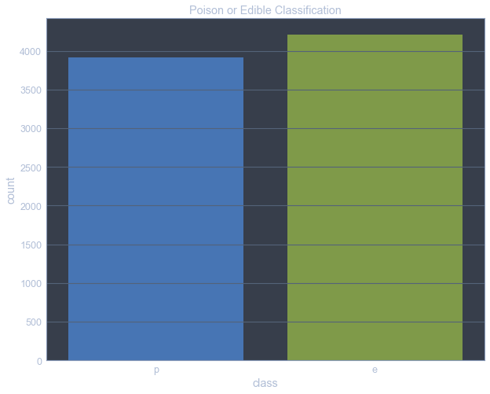

```python
# Plot the initial class for the dataset
x = df['class']
plt.figure(figsize=(10,8))
ax = sns.countplot(x=x, data=df)
plt.title('Poison or Edible Classification')
```

```python
# Print the count in each class
print(df.groupby('class').size())
```

```
class
e    4208
p    3916
dtype: int64
```

```python
# Write a function to plot classes vs. features
def plot_data(hue, data):
    for i, col in enumerate(data.columns):
        plt.figure(i)
        from jupyterthemes import jtplot
        jtplot.style(theme='onedork')
        plt.figure(figsize=(10,8))
        ax = sns.countplot(x=df[col], hue=hue, data=df)
```

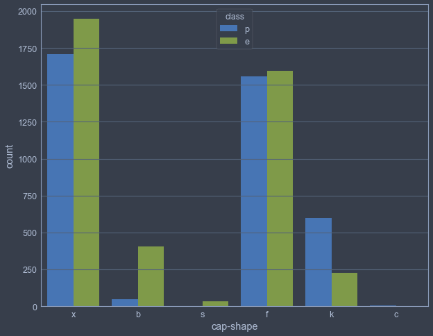

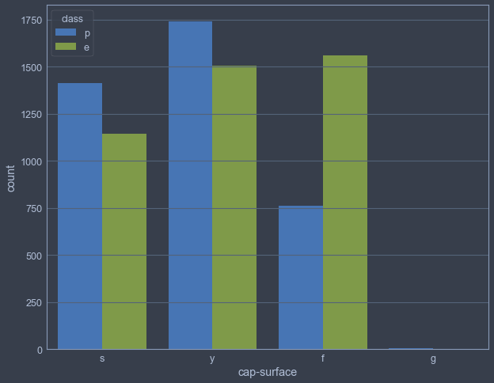

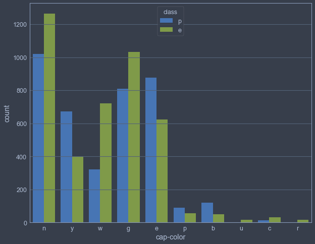

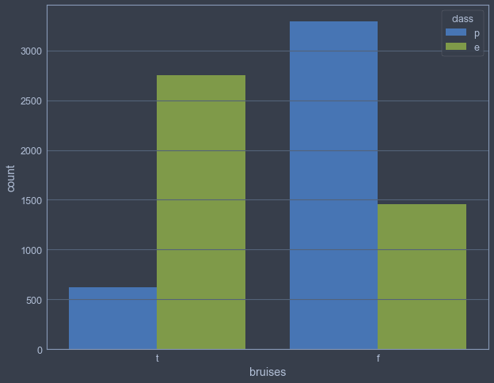

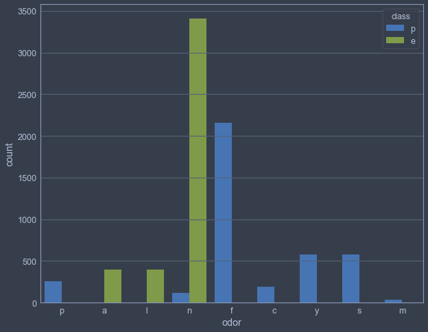

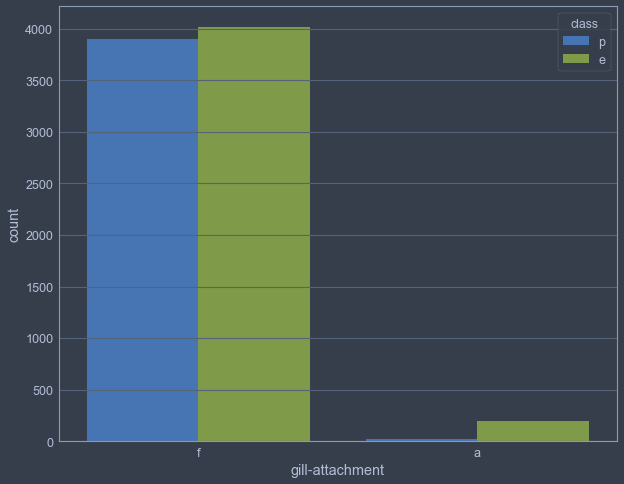

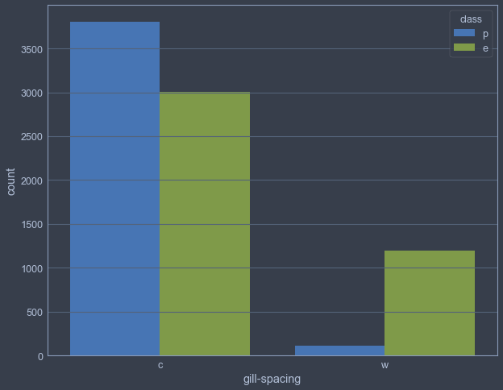

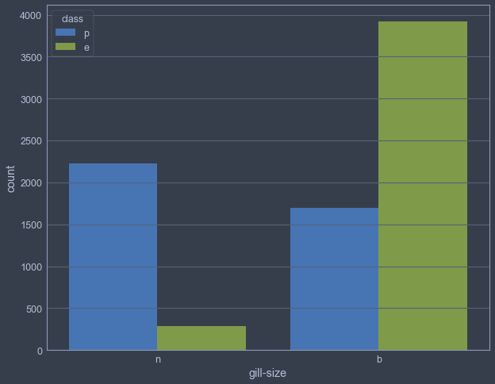

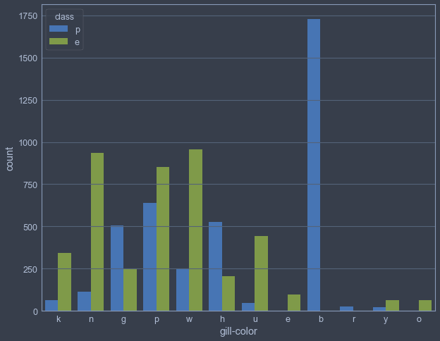

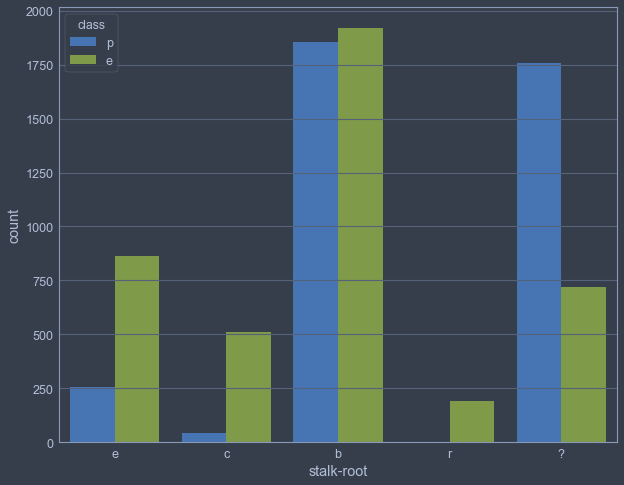

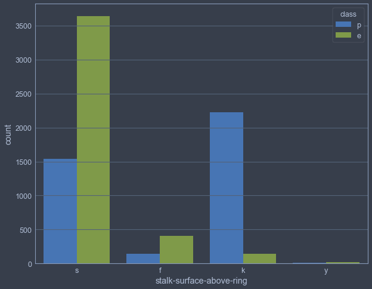

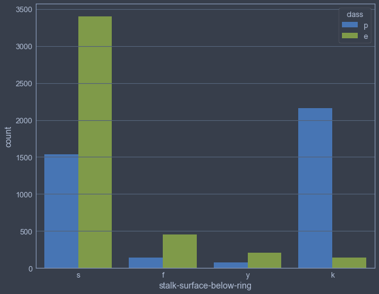

[6 more figures not shown]

```python
# Plot the features in which hue is idenitfied as 'class'
hue = df['class']
dataplot = df.drop('class', 1)
plot_data(hue, dataplot)
```

**Cap Shape**: There are certainly not very many characteristics of cap shape that could definitively decide if the mushroom is poisonous or edible. If the mushroom is knobbed, more often than not it could be poisonous. A bell shaped cap is more likely to be edible.

**Cap Surface**: If the mushroom has a more fibrous surface, it’s more likely to be edible. Smooth and scaly mushrooms are slightly more likely to be poisonous.

**Cap Color**: If the mushroom has a more white or gray surface, it’s likely to be edible. Red or yellow cap colors tend to be more poisonous.

**Bruises**: If the mushroom has bruises, it’s likely to be edible. If the mushroom does not have bruises, it’s more likely to be poisonous.

**Odor**: If the mushroom has no odor, it’s extremely likely to be edible. Any odor that is foul or pungent is highly likely to be poisonous.

**Gill Attachments**: There are no characteristics that could definitively classify the mushroom as edible or poisonous.

**Gill Spacing**: If the gills are closely spaced, it’s like to be poisonous. If they are crowded, then it’s more likely to be edible.

**Gill Size**: If the gills are narrow, it’s like to be poisonous. If they are broad, then it’s more likely to be edible.

**Gill Color**: Colors of buff are almost certain to be poisonous. Gray and chocolate colors are also likely to be poisonous. White, purple, and brown colors are likely to be edible.

**Stalk Root**: Missing roots are very likely to be poisonous. Club and equal roots are likely to be edible.

**Stalk Surface Above Ring**: Smooth stalks above the ring will likely be edible. Silky stalks are likely to be poisonous.

**Stalk Surface Below Ring**: Smooth stalks above the ring will likely be edible. Silky stalks are likely to be poisonous.

**Stalk Color Above Ring**: White and gray colors are likely to be edible. Buff, brown, and purple are likely to be poisonous.

**Stalk Color Below Ring**: White and gray colors are likely to be edible. Buff, brown, and purple are likely to be poisonous.

**Ring Type**: Pendant ring types are very likely to be edible. Evanescent and large ring types are likely to be poisonous.

**Spore Print Color**: Black and brown are highly likely to be edible. Tan and white colors are highly likely to be poisonous.

**Population**: Several mushrooms found in the population are likely to be poisonous. Numerous and abundant are likely to be edible.

**Habitat**: Mushrooms found in grasses and woody areas are likely to be edible. Mushrooms found on paths and leaves are likely to be poisonous.

## Important Features

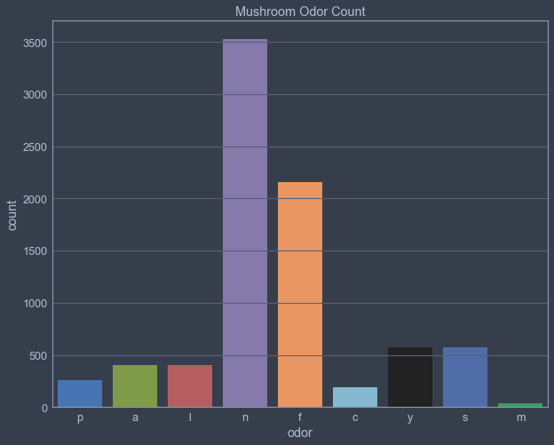

```python
# Plot the count for odor
x = df['odor']
plt.figure(figsize=(10,8))
ax = sns.countplot(x=x, data=df)
plt.title('Mushroom Odor Count')
```

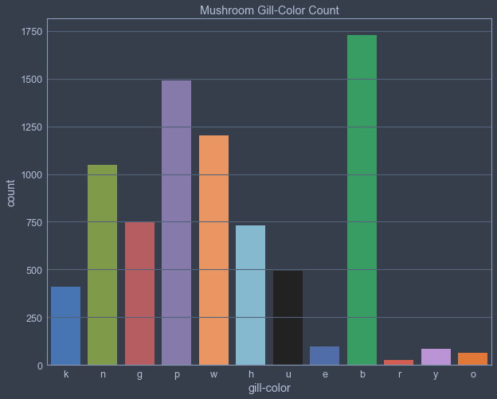

```python
# Plot the count for Gill-Color
x = df['gill-color']
plt.figure(figsize=(10,8))
ax = sns.countplot(x=x, data=df)
plt.title('Mushroom Gill-Color Count')
```

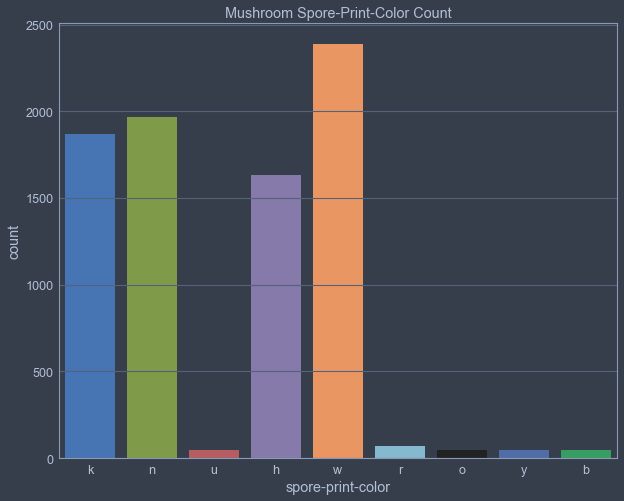

```python
# Plot the count for Spore Print Color
x = df['spore-print-color']
plt.figure(figsize=(10,8))
ax = sns.countplot(x=x, data=df)
plt.title('Mushroom Spore-Print-Color Count')
```

# **Model Preparation**

The mushroom dataset is primarily categorical data. These data types are not ideal for model building, therefore, the data must be converted into numerical data types. This can be done using Label and One-Hot encoding.

## Label Encoding

Most Machine Learning algorithms require numerical features. However, the dataset is composed of categorical features. We now must proceed to convert these to numerical data types.

A typical approach is to perform *Label Encoding*. This is nothing more than just assigning a number to each category, that is:

(cat_a, cat_b, cat_c, etc.) → (0, 1, 2, etc.)

This technique works:

- When the features are binary (only have 2 unique values).
- When the features are *ordinal categorical* (that is, when the categories can be ranked). A good example would be a feature called *t-shirt size* with 3 unique values *small*, *medium* or *large*, which have an intrinsic order.

**However**, in this case, only some of our features have 2 unique values (most of them have more), and none of them are *ordinal categorical* (in fact they they are *nominal categorical*, which means they have no intrinsic order).

```python
# Write a loop that creates binary class for columns with value counts==2
# Quick Label encoding
labelencoder=LabelEncoder()
for col in df.columns:
    df[col] = labelencoder.fit_transform(df[col])

df.head()
```

|  | class | cap-shape | cap-surface | cap-color | bruises | odor | gill-attachment | gill-spacing | gill-size | gill-color | stalk-root | stalk-surface-above-ring | stalk-surface-below-ring | stalk-color-above-ring | stalk-color-below-ring | ring-type | spore-print-color | population | habitat |
| --- | --- | --- | --- | --- | --- | --- | --- | --- | --- | --- | --- | --- | --- | --- | --- | --- | --- | --- | --- |
| 0 | 1 | 5 | 2 | 4 | 1 | 6 | 1 | 0 | 1 | 4 | 3 | 2 | 2 | 7 | 7 | 4 | 2 | 3 | 5 |
| 1 | 0 | 5 | 2 | 9 | 1 | 0 | 1 | 0 | 0 | 4 | 2 | 2 | 2 | 7 | 7 | 4 | 3 | 2 | 1 |
| 2 | 0 | 0 | 2 | 8 | 1 | 3 | 1 | 0 | 0 | 5 | 2 | 2 | 2 | 7 | 7 | 4 | 3 | 2 | 3 |
| 3 | 1 | 5 | 3 | 8 | 1 | 6 | 1 | 0 | 1 | 5 | 3 | 2 | 2 | 7 | 7 | 4 | 2 | 3 | 5 |
| 4 | 0 | 5 | 2 | 3 | 0 | 5 | 1 | 1 | 0 | 4 | 3 | 2 | 2 | 7 | 7 | 0 | 3 | 0 | 1 |

We can see how label encoding has converted some of the features to values of 0 or 1. More importantly, our labels (the class column) are now 0=e, and 1=p. Other features are encoded into a numerical value based upon their categorical values. (See Below).

```python
# Find unique values for a 'random' column
df['ring-type'].unique()
```

```
array([4, 0, 2, 1, 3])
```

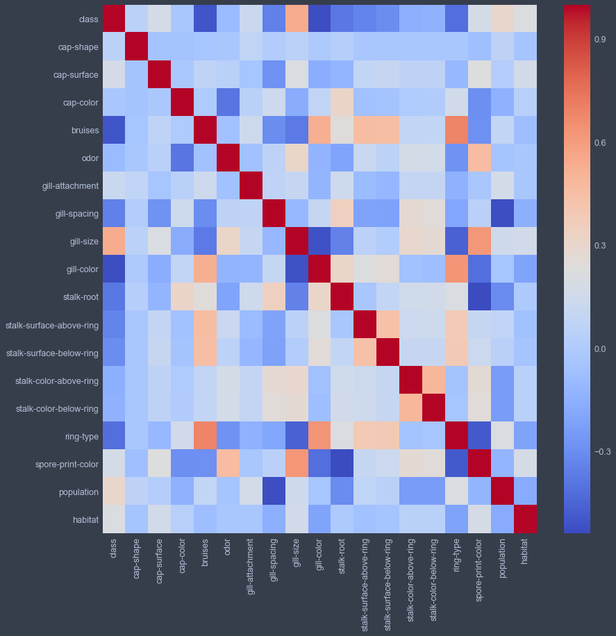

```python
# Set correlation variable
corr = df.corr()

# Plot the heatmap
plt.figure(figsize=(14,14))
sns.heatmap(corr,
        xticklabels=corr.columns,
        yticklabels=corr.columns,
        cmap='coolwarm')
```

## Separate Labels

The variable X will contain the features and variable y will contain the labels (0 for edible and 1 for poisonous/unknown).

```python
# Separate labels into X and y
X = df.iloc[:,1:18]  # all rows, all the features and no labels
y = df.iloc[:, 0]  # all rows, label only
```

```python
X.head()
```

|  | cap-shape | cap-surface | cap-color | bruises | odor | gill-attachment | gill-spacing | gill-size | gill-color | stalk-root | stalk-surface-above-ring | stalk-surface-below-ring | stalk-color-above-ring | stalk-color-below-ring | ring-type | spore-print-color | population |
| --- | --- | --- | --- | --- | --- | --- | --- | --- | --- | --- | --- | --- | --- | --- | --- | --- | --- |
| 0 | 5 | 2 | 4 | 1 | 6 | 1 | 0 | 1 | 4 | 3 | 2 | 2 | 7 | 7 | 4 | 2 | 3 |
| 1 | 5 | 2 | 9 | 1 | 0 | 1 | 0 | 0 | 4 | 2 | 2 | 2 | 7 | 7 | 4 | 3 | 2 |
| 2 | 0 | 2 | 8 | 1 | 3 | 1 | 0 | 0 | 5 | 2 | 2 | 2 | 7 | 7 | 4 | 3 | 2 |
| 3 | 5 | 3 | 8 | 1 | 6 | 1 | 0 | 1 | 5 | 3 | 2 | 2 | 7 | 7 | 4 | 2 | 3 |
| 4 | 5 | 2 | 3 | 0 | 5 | 1 | 1 | 0 | 4 | 3 | 2 | 2 | 7 | 7 | 0 | 3 | 0 |

```python
X.describe()
```

|  | cap-shape | cap-surface | cap-color | bruises | odor | gill-attachment | gill-spacing | gill-size | gill-color | stalk-root | stalk-surface-above-ring | stalk-surface-below-ring | stalk-color-above-ring | stalk-color-below-ring | ring-type | spore-print-color | population |
| --- | --- | --- | --- | --- | --- | --- | --- | --- | --- | --- | --- | --- | --- | --- | --- | --- | --- |
| count | 8124.000000 | 8124.000000 | 8124.000000 | 8124.000000 | 8124.000000 | 8124.000000 | 8124.000000 | 8124.000000 | 8124.000000 | 8124.000000 | 8124.000000 | 8124.000000 | 8124.000000 | 8124.000000 | 8124.000000 | 8124.000000 | 8124.000000 |
| mean | 3.348104 | 1.827671 | 4.504677 | 0.415559 | 4.144756 | 0.974151 | 0.161497 | 0.309207 | 4.810684 | 1.109798 | 1.575086 | 1.603644 | 5.816347 | 5.794682 | 2.291974 | 3.596750 | 3.644018 |
| std | 1.604329 | 1.229873 | 2.545821 | 0.492848 | 2.103729 | 0.158695 | 0.368011 | 0.462195 | 3.540359 | 1.061106 | 0.621459 | 0.675974 | 1.901747 | 1.907291 | 1.801672 | 2.382663 | 1.252082 |
| min | 0.000000 | 0.000000 | 0.000000 | 0.000000 | 0.000000 | 0.000000 | 0.000000 | 0.000000 | 0.000000 | 0.000000 | 0.000000 | 0.000000 | 0.000000 | 0.000000 | 0.000000 | 0.000000 | 0.000000 |
| 25% | 2.000000 | 0.000000 | 3.000000 | 0.000000 | 2.000000 | 1.000000 | 0.000000 | 0.000000 | 2.000000 | 0.000000 | 1.000000 | 1.000000 | 6.000000 | 6.000000 | 0.000000 | 2.000000 | 3.000000 |
| 50% | 3.000000 | 2.000000 | 4.000000 | 0.000000 | 5.000000 | 1.000000 | 0.000000 | 0.000000 | 5.000000 | 1.000000 | 2.000000 | 2.000000 | 7.000000 | 7.000000 | 2.000000 | 3.000000 | 4.000000 |
| 75% | 5.000000 | 3.000000 | 8.000000 | 1.000000 | 5.000000 | 1.000000 | 0.000000 | 1.000000 | 7.000000 | 1.000000 | 2.000000 | 2.000000 | 7.000000 | 7.000000 | 4.000000 | 7.000000 | 4.000000 |
| max | 5.000000 | 3.000000 | 9.000000 | 1.000000 | 8.000000 | 1.000000 | 1.000000 | 1.000000 | 11.000000 | 4.000000 | 3.000000 | 3.000000 | 8.000000 | 8.000000 | 4.000000 | 8.000000 | 5.000000 |

```python
y.head()
```

```
0    1
1    0
2    0
3    1
4    0
Name: class, dtype: int64
```

## Standardize Features

It is generally considered a good practice to standardize features (convert them to have zero-mean and unit variance). Most of the times, the difference will be small, but in any case, it still never hurts to do so.

```python
# Convert data to have zero mean and unit variance
scaler = StandardScaler()
X_scaled = scaler.fit_transform(X)
X_scaled
```

```
array([[ 1.02971224,  0.14012794, -0.19824983, ...,  0.94808086,
        -0.67019486, -0.5143892 ],
       [ 1.02971224,  0.14012794,  1.76587407, ...,  0.94808086,
        -0.2504706 , -1.31310821],
       [-2.08704716,  0.14012794,  1.37304929, ...,  0.94808086,
        -0.2504706 , -1.31310821],
       ...,
       [-0.8403434 ,  0.14012794, -0.19824983, ...,  0.94808086,
        -1.50964337, -2.11182722],
       [-0.21699152,  0.95327039, -0.19824983, ..., -1.27221574,
         1.42842641,  0.28432981],
       [ 1.02971224,  0.14012794, -0.19824983, ...,  0.94808086,
         0.16925365, -2.11182722]])
```

## Training and Test Data

We will separate our data into a training set (70%) and a test set (30%). This is a very standard approach in Machine Learning.

The stratify option ensures that the ratio of edible to poisonous mushrooms in our dataset remains the same in both training and test sets. The random_state parameter is simply a seed for the algorithm to use (if we didn't specify one, it would create different training and test sets every time we run it)

```python
# Split the data into trains and tests
X_train, X_test, y_train, y_test = train_test_split(X_scaled, y, test_size=0.3, stratify=y, random_state=19)
print(y_train.value_counts(),'\n', y_test.value_counts())
```

```
0    2945
1    2741
Name: class, dtype: int64
 0    1263
1    1175
Name: class, dtype: int64
```

# **Logistic Regression**

Logistic Regression is a classification algorithm used where the response variable is categorical. The idea of Logistic Regression is to find a relationship between features and probability of particular outcome. This type of problem is referred to as Binomial Logistic Regression, where the response variable has two values 0 and 1 or pass and fail or true and false.

Since this is a supervised learning binary classification problem, it makes sense to start running logistic regression.The models used here simply predicts the probability of an instance (row) belonging to the default class, which can then be snapped into a 0 or 1 classification. For this case, a 0 classification will signifies the mushroom is edible and a 1 classification signifies the mushroom is poisonous, thus inedible.

The following three models are completed using Logistic regression, however they differ slightly.

- The LR Normal model is a default logistic regression model using sklearn.
- The LR Tuned model imposes a penalty on the coefficients to prevent overfitting.
- The LR Lasso model performs variable selection by shrinking some coefficients.

With the proceeding models you will see the following: AUC - ROC curve is a performance measurement for classification problem at various thresholds settings. ROC is a probability curve and AUC represents degree or measure of separability. It tells how much the model is capable of distinguishing between classes. Higher the AUC, better the model is at predicting 0s as 0s and 1s as 1s. By analogy, Higher the AUC, better the model is at distinguishing between mushroom edibility.

## LR Normal

```python
# Fit a default LogReg model
lr_normal = LogisticRegression()
lr_normal.fit(X_train,y_train)
```

```
LogisticRegression(C=1.0, class_weight=None, dual=False, fit_intercept=True,
                   intercept_scaling=1, l1_ratio=None, max_iter=100,
                   multi_class='warn', n_jobs=None, penalty='l2',
                   random_state=None, solver='warn', tol=0.0001, verbose=0,
                   warm_start=False)
```

```python
# Retrieve the accuracy score of the LR model
y_prob = lr_normal.predict_proba(X_test)[:,1] # This will give you positive class prediction probabilities
y_pred = np.where(y_prob > 0.5, 1, 0) # This will threshold the probabilities to give class predictions.
print('The accuracy of LR Normal is', lr_normal.score(X_test, y_pred)*100)
```

```
The accuracy of LR Normal is 100.0
```

```python
# Plot the confusion matrix
confusion_matrix = metrics.confusion_matrix(y_test,y_pred)
print(confusion_matrix)
```

```
[[1204   59]
 [  84 1091]]
```

```python
# Retrieve the AUC score
auc_roc=metrics.roc_auc_score(y_test,y_pred)
auc_roc
```

```
0.9408982328464818
```

```python
# Retrieve the ROC score
false_positive_rate, true_positive_rate, thresholds = roc_curve(y_test, y_prob)
roc_auc = auc(false_positive_rate, true_positive_rate)
roc_auc
```

```
0.9754977173565135
```

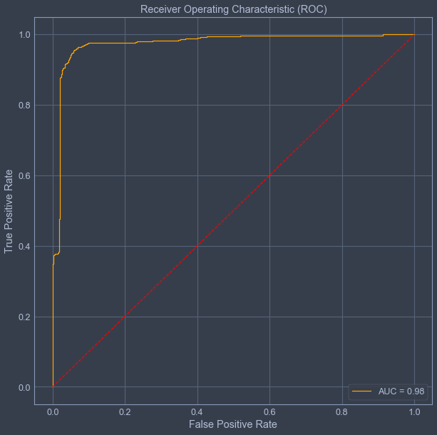

```python
# Plot the ROC Curve
plt.figure(figsize=(10,10))
plt.title('Receiver Operating Characteristic (ROC)')
plt.plot(false_positive_rate,true_positive_rate, color='orange',label = 'AUC = %0.2f' % roc_auc)
plt.legend(loc = 'lower right')
plt.plot([0, 1], [0, 1],linestyle='--', c='red')
plt.axis('tight')
plt.ylabel('True Positive Rate')
plt.xlabel('False Positive Rate')
```

## LR Tuned

L1 and L2 are regularization parameters and are used to avoid overfiting. Both L1 and L2 regularization prevents overfitting by shrinking (imposing a penalty) on the coefficients.

L2 (Ridge) shrinks the coefficients by the same proportions but eliminates none, while L1 (Lasso) can shrink some coefficients to zero, performing variable selection. If all the features are correlated with the label, ridge outperforms lasso, as the coefficients are never zero in ridge. If only a subset of features are correlated with the label, lasso outperforms ridge as in lasso model some coefficient can be shrunken to zero.

```python
# Use tuned parameters in logreg model
lr_tuned = LogisticRegression()

tuned_parameters = {'C': [0.001, 0.01, 0.1, 1, 10, 100, 1000] ,
              'penalty':['l1','l2']
                   }
```

Grid search with GridSearchCV exhaustively generates candidates from a grid of parameter values specified with the tuned_parameter. The GridSearchCV instance implements the usual estimator when “fitting” it on a dataset all the possible combinations of parameter values are evaluated and the best combination is retained.

```python
# Use Grid Search for logreg
lr_tuned = GridSearchCV(lr_tuned, tuned_parameters, cv=10)
```

```python
# Fit a default LogReg model
lr_tuned.fit(X_train,y_train)
```

```
GridSearchCV(cv=10, error_score='raise-deprecating',
             estimator=LogisticRegression(C=1.0, class_weight=None, dual=False,
                                          fit_intercept=True,
                                          intercept_scaling=1, l1_ratio=None,
                                          max_iter=100, multi_class='warn',
                                          n_jobs=None, penalty='l2',
                                          random_state=None, solver='warn',
                                          tol=0.0001, verbose=0,
                                          warm_start=False),
             iid='warn', n_jobs=None,
             param_grid={'C': [0.001, 0.01, 0.1, 1, 10, 100, 1000],
                         'penalty': ['l1', 'l2']},
             pre_dispatch='2*n_jobs', refit=True, return_train_score=False,
             scoring=None, verbose=0)
```

```python
# Print the best parameters
print(lr_tuned.best_params_)
```

```
{'C': 100, 'penalty': 'l1'}
```

```python
# Get the accuracy of the model
y_prob = lr_tuned.predict_proba(X_test)[:,1] # This will give you positive class prediction probabilities
y_pred = np.where(y_prob > 0.5, 1, 0) # This will threshold the probabilities to give class predictions.
print('The accuracy of the LR Model is', lr_tuned.score(X_test, y_pred)*100)
```

```
The accuracy of the LR Model is 100.0
```

```python
# Identify the confusion matrix
confusion_matrix = metrics.confusion_matrix(y_test,y_pred)
print(confusion_matrix)
```

```
[[1207   56]
 [  87 1088]]
```

```python
# Print the precision and recall scores
auc_roc = metrics.classification_report(y_test,y_pred)
print(auc_roc)
```

```
              precision    recall  f1-score   support

           0       0.93      0.96      0.94      1263
           1       0.95      0.93      0.94      1175

    accuracy                           0.94      2438
   macro avg       0.94      0.94      0.94      2438
weighted avg       0.94      0.94      0.94      2438
```

```python
# Print the roc/auc true and false positive rates
false_positive_rate, true_positive_rate, thresholds = roc_curve(y_test, y_prob)
roc_auc = auc(false_positive_rate, true_positive_rate)
roc_auc
```

```
0.9771324607065246
```

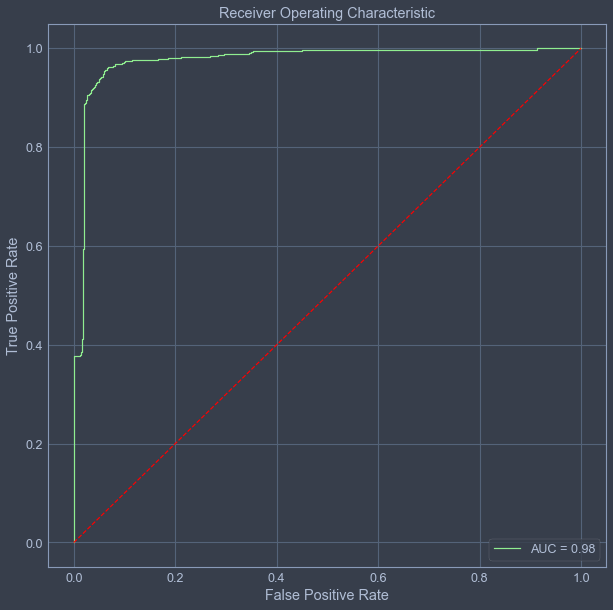

```python
# Plot the ROC curve including the false/true positive rates
plt.figure(figsize=(10,10))
plt.title('Receiver Operating Characteristic')
plt.plot(false_positive_rate,true_positive_rate, color='lightgreen',label = 'AUC = %0.2f' % roc_auc)
plt.legend(loc = 'lower right')
plt.plot([0, 1], [0, 1],linestyle='--', color='red')
plt.axis('tight')
plt.ylabel('True Positive Rate')
plt.xlabel('False Positive Rate')
```

## LR Lasso

```python
# Fit a lasso LogReg model
lr_lasso = LogisticRegression(C=100, penalty='l1')
lr_lasso.fit(X_train,y_train.values.ravel())
```

```
LogisticRegression(C=100, class_weight=None, dual=False, fit_intercept=True,
                   intercept_scaling=1, l1_ratio=None, max_iter=100,
                   multi_class='warn', n_jobs=None, penalty='l1',
                   random_state=None, solver='warn', tol=0.0001, verbose=0,
                   warm_start=False)
```

```python
# Get the accuracy of the model
y_prob = lr_lasso.predict_proba(X_test)[:,1] # This will give positive class prediction probabilities
y_pred = np.where(y_prob > 0.5, 1, 0) # This will threshold the probabilities to give class predictions
lr_lasso.score(X_test, y_pred)
```

```
1.0
```

```python
# Plot the confusion matrix
confusion_matrix = metrics.confusion_matrix(y_test,y_pred)
confusion_matrix
```

```
array([[1207,   56],
       [  87, 1088]])
```

```python
# Print the precision and recall scores
auc_roc = metrics.classification_report(y_test,y_pred)
print(auc_roc)
```

```
              precision    recall  f1-score   support

           0       0.93      0.96      0.94      1263
           1       0.95      0.93      0.94      1175

    accuracy                           0.94      2438
   macro avg       0.94      0.94      0.94      2438
weighted avg       0.94      0.94      0.94      2438
```

```python
# Print the roc/auc true and false positive rates
false_positive_rate, true_positive_rate, thresholds = roc_curve(y_test, y_prob)
roc_auc = auc(false_positive_rate, true_positive_rate)
print(roc_auc)
```

```
0.9771216792169943
```

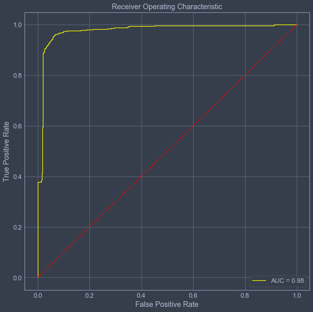

```python
# Plot the ROC Curve
plt.figure(figsize=(10,10))
plt.title('Receiver Operating Characteristic')
plt.plot(false_positive_rate,true_positive_rate, color='yellow',label = 'AUC = %0.2f' % roc_auc)
plt.legend(loc = 'lower right')
plt.plot([0, 1], [0, 1],linestyle='--', c='red')
plt.axis('tight')
plt.ylabel('True Positive Rate')
plt.xlabel('False Positive Rate')
```

```python
# Identify top performing features
feature_coeff = pd.DataFrame(lr_lasso.coef_, columns = X.columns, index = ['coefficients'])
feature_coeff.sort_values('coefficients', axis=1, ascending=False, inplace=True)
feature_coeff.T.head()
```

|  | coefficients |
| --- | --- |
| gill-size | 4.969451 |
| ring-type | 3.178934 |
| gill-attachment | 0.742092 |
| cap-surface | 0.504364 |
| bruises | 0.090325 |

```python
# Identify bottom performing features
feature_coeff.T.tail()
```

|  | coefficients |
| --- | --- |
| population | -0.889592 |
| odor | -1.538272 |
| stalk-root | -3.417774 |
| gill-spacing | -4.038177 |
| stalk-surface-above-ring | -4.440260 |

# **Support Vector Machine**

A Support Vector Machine (SVM) is a discriminative classifier formally defined by a separating hyperplane. In other words, given labeled training data (supervised learning), the algorithm outputs an optimal hyperplane which categorizes new examples. In two dimensional space this hyperplane is a line dividing a plane in two parts where in each class lay in either side.

**Parameters**:

- The *Regularization* parameter (often termed as C parameter in python’s sklearn library) tells the SVM optimization how much you want to avoid misclassifying each training example. For large values of C, the optimization will choose a smaller-margin hyperplane if that hyperplane does a better job of getting all the training points classified correctly. Conversely, a very small value of C will cause the optimizer to look for a larger-margin separating hyperplane, even if that hyperplane mis-classifies more points.
- The learning of the hyperplane in linear SVM is done by transforming the problem using some linear algebra. This is where the *Kernel* plays role. Polynomial kernels calculates separation line in higher dimension. This is called kernel trick.
- The *Gamma* parameter defines how far the influence of a single training example reaches, with low values meaning ‘far’ and high values meaning ‘close’. In other words, with low gamma, points far away from plausible seperation line are considered in calculation for the seperation line. Where as high gamma means the points close to plausible line are considered in calculation.
- *Margin* is the last but very importrant characteristic of SVM classifier. SVM to core tries to achieve a good margin. A margin is a separation of line to the closest class points. A good margin is one where this separation is larger for both the classes.

**RandomizedSearchCV** implements a “fit” and a “score” method. It also implements “predict”, “predict_proba”, “decision_function”, “transform” and “inverse_transform” if they are implemented in the estimator used. The parameters of the estimator used to apply these methods are optimized by cross-validated search over parameter settings.In contrast to GridSearchCV, not all parameter values are tried out, but rather a fixed number of parameter settings is sampled from the specified distributions. The number of parameter settings that are tried is given by n_iter. If all parameters are presented as a list, sampling without replacement is performed. If at least one parameter is given as a distribution, sampling with replacement is used.

## Non-Polynomial

```python
npsvm_model = SVC()
```

```python
tuned_parameters = {
 'C': [1, 10, 100,500, 1000], 'kernel': ['linear','rbf'],
 'C': [1, 10, 100,500, 1000], 'gamma': [1,0.1,0.01,0.001, 0.0001], 'kernel': ['rbf'],}
```

```python
npsvm_model = RandomizedSearchCV(npsvm_model, tuned_parameters,
                               cv=10, scoring='accuracy', n_iter=20)
```

```python
npsvm_model.fit(X_train, y_train)
print(npsvm_model.best_score_)
```

```
0.9994723883221949
```

```python
print(npsvm_model.best_params_)
```

```
{'kernel': 'rbf', 'gamma': 0.1, 'C': 10}
```

```python
y_pred = npsvm_model.predict(X_test)
print(metrics.accuracy_score(y_pred,y_test))
```

```
1.0
```

```python
confusion_matrix = metrics.confusion_matrix(y_test,y_pred)
confusion_matrix
```

```
array([[1263,    0],
       [   0, 1175]])
```

```python
auc_roc = metrics.classification_report(y_test,y_pred)
print(auc_roc)
```

```
              precision    recall  f1-score   support

           0       1.00      1.00      1.00      1263
           1       1.00      1.00      1.00      1175

    accuracy                           1.00      2438
   macro avg       1.00      1.00      1.00      2438
weighted avg       1.00      1.00      1.00      2438
```

```python
false_positive_rate, true_positive_rate, thresholds = roc_curve(y_test, y_pred)
roc_auc = auc(false_positive_rate, true_positive_rate)
roc_auc
```

```
1.0
```

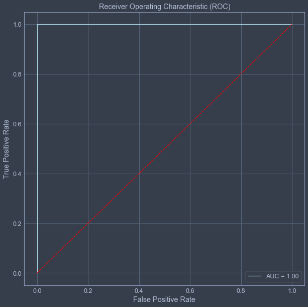

```python
plt.figure(figsize=(10,10))
plt.title('Receiver Operating Characteristic (ROC)')
plt.plot(false_positive_rate,true_positive_rate, color='lightblue',label = 'AUC = %0.2f' % roc_auc)
plt.legend(loc = 'lower right')
plt.plot([0, 1], [0, 1],linestyle='--', c='red')
plt.axis('tight')
plt.ylabel('True Positive Rate')
plt.xlabel('False Positive Rate')
```

## Polynomial

```python
psvm_model = SVC()
```

```python
tuned_parameters = {
 'C': [1, 10, 100,500, 1000], 'kernel': ['linear','rbf'],
 'C': [1, 10, 100,500, 1000], 'gamma': [1,0.1,0.01,0.001, 0.0001], 'kernel': ['rbf'],
 'degree': [2,3,4,5,6] , 'C':[1,10,100,500,1000] , 'kernel':['poly']}
```

```python
psvm_model = RandomizedSearchCV(psvm_model, tuned_parameters, cv=10, scoring='accuracy', n_iter=20)
```

```python
psvm_model.fit(X_train, y_train)
print(psvm_model.best_score_)
```

```
1.0
```

```python
print(psvm_model.best_params_)
```

```
{'kernel': 'poly', 'gamma': 0.1, 'degree': 4, 'C': 100}
```

```python
y_pred = psvm_model.predict(X_test)
print(metrics.accuracy_score(y_pred,y_test))
```

```
1.0
```

```python
confusion_matrix = metrics.confusion_matrix(y_test,y_pred)
confusion_matrix
```

```
array([[1263,    0],
       [   0, 1175]])
```

```python
auc_roc = metrics.classification_report(y_test,y_pred)
print(auc_roc)
```

```
              precision    recall  f1-score   support

           0       1.00      1.00      1.00      1263
           1       1.00      1.00      1.00      1175

    accuracy                           1.00      2438
   macro avg       1.00      1.00      1.00      2438
weighted avg       1.00      1.00      1.00      2438
```

```python
auc_roc = metrics.roc_auc_score(y_test,y_pred)
auc_roc
```

```
1.0
```

```python
false_positive_rate, true_positive_rate, thresholds = roc_curve(y_test, y_pred)
roc_auc = auc(false_positive_rate, true_positive_rate)
roc_auc
```

```
1.0
```

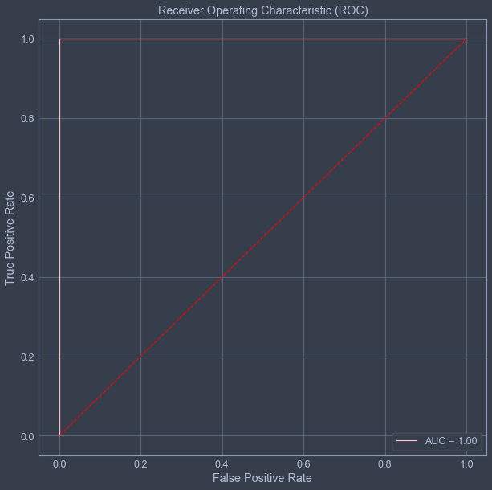

```python
plt.figure(figsize=(10,10))
plt.title('Receiver Operating Characteristic (ROC)')
plt.plot(false_positive_rate,true_positive_rate, color='pink',label = 'AUC = %0.2f' % roc_auc)
plt.legend(loc = 'lower right')
plt.plot([0, 1], [0, 1],linestyle='--', c='red')
plt.axis('tight')
plt.ylabel('True Positive Rate')
plt.xlabel('False Positive Rate')
```

# **Decision Trees**

In decision analysis, a decision tree can be used to visually and explicitly represent decisions and decision making. As the name goes, it uses a tree-like model of decisions. A decision tree is a tree where each node represents a feature(attribute), each link(branch) represents a decision(rule) and each leaf represents an outcome(categorical or continues value). The idea is to create a tree for the entire data and process a single outcome at every leaf, minimizing error.

There are couple of algorithms used to build decision trees. In this mushroom classification, we will use two different criterion for tuning parameters. These models use Gini indexing and Entropy:

- CART (Classification and Regression Trees) → uses Gini Index (Classification) as metric.
- ID3 (Iterative Dichotomiser 3) → uses Entropy function and information gain as metrics.

## Default Tree

```python
tree_model = DecisionTreeClassifier()
```

```python
tree_model.fit(X_train, y_train)
```

```
DecisionTreeClassifier(class_weight=None, criterion='gini', max_depth=None,
                       max_features=None, max_leaf_nodes=None,
                       min_impurity_decrease=0.0, min_impurity_split=None,
                       min_samples_leaf=1, min_samples_split=2,
                       min_weight_fraction_leaf=0.0, presort=False,
                       random_state=None, splitter='best')
```

```python
y_prob = tree_model.predict_proba(X_test)[:,1] # This will give you positive class prediction probabilities
y_pred = np.where(y_prob > 0.5, 1, 0) # This will threshold the probabilities to give class predictions.
tree_model.score(X_test, y_pred)
```

```
1.0
```

```python
confusion_matrix=metrics.confusion_matrix(y_test,y_pred)
confusion_matrix
```

```
array([[1263,    0],
       [   0, 1175]])
```

```python
auc_roc=metrics.classification_report(y_test,y_pred)
print(auc_roc)
```

```
              precision    recall  f1-score   support

           0       1.00      1.00      1.00      1263
           1       1.00      1.00      1.00      1175

    accuracy                           1.00      2438
   macro avg       1.00      1.00      1.00      2438
weighted avg       1.00      1.00      1.00      2438
```

```python
auc_roc=metrics.roc_auc_score(y_test,y_pred)
auc_roc
```

```
1.0
```

```python
false_positive_rate, true_positive_rate, thresholds = roc_curve(y_test, y_prob)
roc_auc = auc(false_positive_rate, true_positive_rate)
```

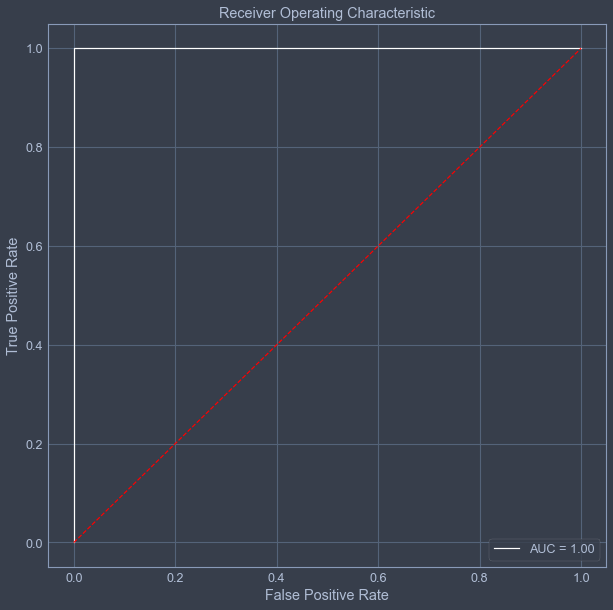

```python
plt.figure(figsize=(10,10))
plt.title('Receiver Operating Characteristic')
plt.plot(false_positive_rate,true_positive_rate, color='white',label = 'AUC = %0.2f' % roc_auc)
plt.legend(loc = 'lower right')
plt.plot([0, 1], [0, 1],linestyle='--', c='red')
plt.axis('tight')
plt.ylabel('True Positive Rate')
plt.xlabel('False Positive Rate')
```

## Tuned Tree

```python
ttree_model = DecisionTreeClassifier()


tuned_parameters= {'criterion': ['gini','entropy'], 'max_features': ["auto","sqrt","log2"],
                   'min_samples_leaf': range(1,100,1) , 'max_depth': range(1,50,1)
                  }
```

```python
ttree_model = RandomizedSearchCV(ttree_model, tuned_parameters,
                                 cv=10, scoring='accuracy',
                                 n_iter=20, random_state=5)
```

```python
ttree_model.fit(X_train, y_train)
```

```
RandomizedSearchCV(cv=10, error_score='raise-deprecating',
                   estimator=DecisionTreeClassifier(class_weight=None,
                                                    criterion='gini',
                                                    max_depth=None,
                                                    max_features=None,
                                                    max_leaf_nodes=None,
                                                    min_impurity_decrease=0.0,
                                                    min_impurity_split=None,
                                                    min_samples_leaf=1,
                                                    min_samples_split=2,
                                                    min_weight_fraction_leaf=0.0,
                                                    presort=False,
                                                    random_state=None,
                                                    splitter='best'),
                   iid='warn', n_iter=20, n_jobs=None,
                   param_distributions={'criterion': ['gini', 'entropy'],
                                        'max_depth': range(1, 50),
                                        'max_features': ['auto', 'sqrt',
                                                         'log2'],
                                        'min_samples_leaf': range(1, 100)},
                   pre_dispatch='2*n_jobs', random_state=5, refit=True,
                   return_train_score=False, scoring='accuracy', verbose=0)
```

```python
print(ttree_model.best_score_)
```

```
0.9947238832219486
```

```python
print(ttree_model.best_params_)
```

```
{'min_samples_leaf': 10, 'max_features': 'log2', 'max_depth': 31, 'criterion': 'entropy'}
```

```python
y_prob = ttree_model.predict_proba(X_test)[:,1] # This will give you positive class prediction probabilities
y_pred = np.where(y_prob > 0.5, 1, 0) # This will threshold the probabilities to give class predictions.
ttree_model.score(X_test, y_pred)
```

```
1.0
```

```python
confusion_matrix = metrics.confusion_matrix(y_test,y_pred)
confusion_matrix
```

```
array([[1248,   15],
       [   4, 1171]])
```

```python
auc_roc = metrics.classification_report(y_test,y_pred)
print(auc_roc)
```

```
              precision    recall  f1-score   support

           0       1.00      0.99      0.99      1263
           1       0.99      1.00      0.99      1175

    accuracy                           0.99      2438
   macro avg       0.99      0.99      0.99      2438
weighted avg       0.99      0.99      0.99      2438
```

```python
auc_roc = metrics.roc_auc_score(y_test,y_pred)
auc_roc
```

```
0.9923596300601405
```

```python
false_positive_rate, true_positive_rate, thresholds = roc_curve(y_test, y_prob)
roc_auc = auc(false_positive_rate, true_positive_rate)
roc_auc
```

```
0.9998372668924042
```

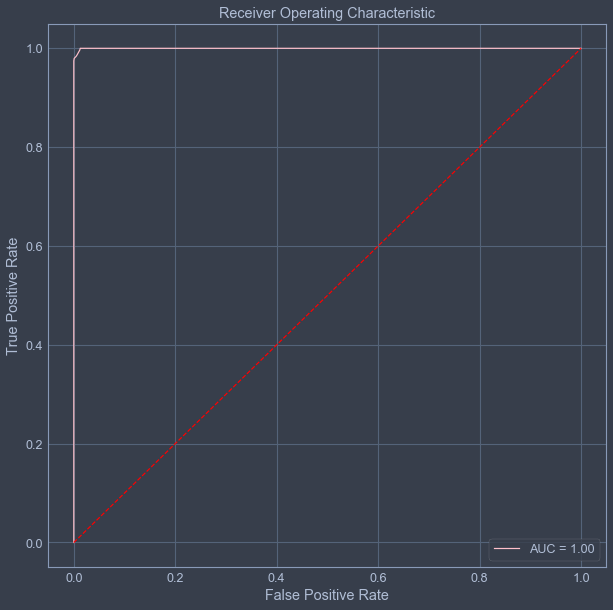

```python
plt.figure(figsize=(10,10))
plt.title('Receiver Operating Characteristic')
plt.plot(false_positive_rate,true_positive_rate, color='pink',label = 'AUC = %0.2f' % roc_auc)
plt.legend(loc = 'lower right')
plt.plot([0, 1], [0, 1],linestyle='--', color='red')
plt.axis('tight')
plt.ylabel('True Positive Rate')
plt.xlabel('False Positive Rate')
```

# **Random Forest**

Random forest, like its name implies, consists of a large number of individual decision trees that operate as an ensemble. Each individual tree in the random forest spits out a class prediction and the class with the most votes becomes our models' prediction. The fundamental concept behind random forest is a simple but powerful one — the reason that the random forest model works so well is that s large number of relatively uncorrelated models (trees) operating as a committee will outperform any of the individual constituent models. The trees protect each other from their individual errors (as long as they don’t constantly all err in the same direction). While some trees may be wrong, many other trees will be right, so as a group the trees are able to move in the correct direction.

## Default Forest

```python
from sklearn.ensemble import RandomForestClassifier

rfc_model = RandomForestClassifier()
```

```python
rfc_model.fit(X_train,y_train)
```

```
RandomForestClassifier(bootstrap=True, class_weight=None, criterion='gini',
                       max_depth=None, max_features='auto', max_leaf_nodes=None,
                       min_impurity_decrease=0.0, min_impurity_split=None,
                       min_samples_leaf=1, min_samples_split=2,
                       min_weight_fraction_leaf=0.0, n_estimators=10,
                       n_jobs=None, oob_score=False, random_state=None,
                       verbose=0, warm_start=False)
```

```python
y_prob = rfc_model.predict_proba(X_test)[:,1] # This will give you positive class prediction probabilities
y_pred = np.where(y_prob > 0.5, 1, 0) # This will threshold the probabilities to give class predictions
rfc_model.score(X_test, y_pred)
```

```
1.0
```

```python
confusion_matrix = metrics.confusion_matrix(y_test,y_pred)
confusion_matrix
```

```
array([[1263,    0],
       [   0, 1175]])
```

```python
auc_roc = metrics.classification_report(y_test,y_pred)
print(auc_roc)
```

```
              precision    recall  f1-score   support

           0       1.00      1.00      1.00      1263
           1       1.00      1.00      1.00      1175

    accuracy                           1.00      2438
   macro avg       1.00      1.00      1.00      2438
weighted avg       1.00      1.00      1.00      2438
```

```python
auc_roc = metrics.roc_auc_score(y_test,y_pred)
auc_roc
```

```
1.0
```

```python
false_positive_rate, true_positive_rate, thresholds = roc_curve(y_test, y_prob)
roc_auc = auc(false_positive_rate, true_positive_rate)
```

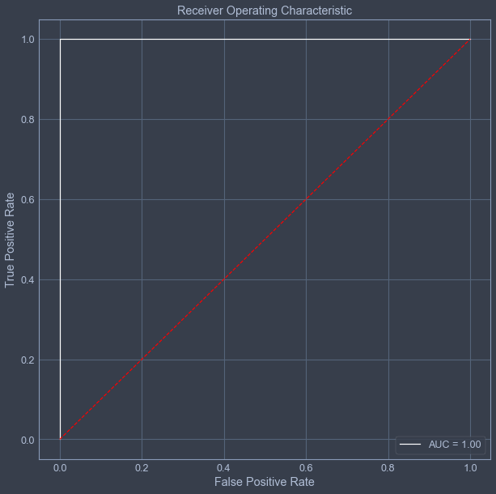

```python
plt.figure(figsize=(10,10))
plt.title('Receiver Operating Characteristic')
plt.plot(false_positive_rate,true_positive_rate, color='white',label = 'AUC = %0.2f' % roc_auc)
plt.legend(loc = 'lower right')
plt.plot([0, 1], [0, 1],linestyle='--', color='red')
plt.axis('tight')
plt.ylabel('True Positive Rate')
plt.xlabel('False Positive Rate')
```

## Tuned Forest

```python
trcf_model=RandomForestClassifier()

tuned_parameters = {'min_samples_leaf': range(10,100,10), 'n_estimators' : range(10,100,10),
                    'max_features':['auto','sqrt','log2']
                    }
```

```python
trcf_model = RandomizedSearchCV(trcf_model, tuned_parameters,cv=10,scoring='accuracy',n_iter=20)
```

```python
trcf_model.fit(X_train,y_train)
```

```
RandomizedSearchCV(cv=10, error_score='raise-deprecating',
                   estimator=RandomForestClassifier(bootstrap=True,
                                                    class_weight=None,
                                                    criterion='gini',
                                                    max_depth=None,
                                                    max_features='auto',
                                                    max_leaf_nodes=None,
                                                    min_impurity_decrease=0.0,
                                                    min_impurity_split=None,
                                                    min_samples_leaf=1,
                                                    min_samples_split=2,
                                                    min_weight_fraction_leaf=0.0,
                                                    n_estimators='warn',
                                                    n_jobs=None,
                                                    oob_score=False,
                                                    random_state=None,
                                                    verbose=0,
                                                    warm_start=False),
                   iid='warn', n_iter=20, n_jobs=None,
                   param_distributions={'max_features': ['auto', 'sqrt',
                                                         'log2'],
                                        'min_samples_leaf': range(10, 100, 10),
                                        'n_estimators': range(10, 100, 10)},
                   pre_dispatch='2*n_jobs', random_state=None, refit=True,
                   return_train_score=False, scoring='accuracy', verbose=0)
```

```python
print(trcf_model.best_score_)
```

```
0.9989447766443897
```

```python
print(trcf_model.best_params_)
```

```
{'n_estimators': 20, 'min_samples_leaf': 10, 'max_features': 'auto'}
```

```python
y_prob = trcf_model.predict_proba(X_test)[:,1] # This will give you positive class prediction probabilities
y_pred = np.where(y_prob > 0.5, 1, 0) # This will threshold the probabilities to give class predictions.
trcf_model.score(X_test, y_pred)
```

```
1.0
```

```python
confusion_matrix=metrics.confusion_matrix(y_test,y_pred)
confusion_matrix
```

```
array([[1262,    1],
       [   4, 1171]])
```

```python
auc_roc=metrics.classification_report(y_test,y_pred)
print(auc_roc)
```

```
              precision    recall  f1-score   support

           0       1.00      1.00      1.00      1263
           1       1.00      1.00      1.00      1175

    accuracy                           1.00      2438
   macro avg       1.00      1.00      1.00      2438
weighted avg       1.00      1.00      1.00      2438
```

```python
auc_roc=metrics.roc_auc_score(y_test,y_pred)
auc_roc
```

```
0.9979019895217399
```

```python
false_positive_rate, true_positive_rate, thresholds = roc_curve(y_test, y_prob)
roc_auc = auc(false_positive_rate, true_positive_rate)
roc_auc
```

```
0.9999973046276174
```

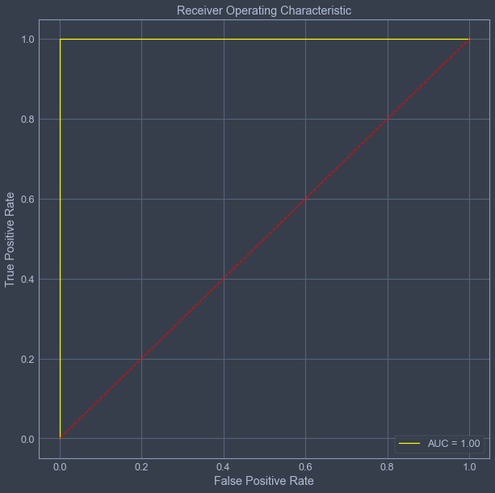

```python
plt.figure(figsize=(10,10))
plt.title('Receiver Operating Characteristic')
plt.plot(false_positive_rate,true_positive_rate, color='yellow',label = 'AUC = %0.2f' % roc_auc)
plt.legend(loc = 'lower right')
plt.plot([0, 1], [0, 1],linestyle='--', color='red')
plt.axis('tight')
plt.ylabel('True Positive Rate')
plt.xlabel('False Positive Rate')
```

# **Conclusion**

Though field experts determine that is that there is no simple set of rules to identify whether a mushroom is edible or not, it seems like with these algorithms we can get pretty close based upon numerical characteristics. The models above identified specific traits that seem to heavily influence the chance that a mushroom could be edible. Specifically, when tuning the logistic regression lasso model, there are a few coefficients identified that play an important role in the classification process.

## Best Models

[output not shown]

Tuned Random Forest - individual decision trees that operate as an ensemble.

[output not shown]